# NYPD Shooting Final Mine

Som Thapa

2023-06-08

### Import Libraries

```r
library(tidyverse)
library(lubridate)
library(ggplot2)
library(corrplot)
library(gridExtra)
```

## Introduction

### Objective

Objective of this project is to

- find any particular age group,Sex and Race account highest number of Perpetrator and Victims
- Find out if there any correlation between perpetrator and Victim Race
- Build Model to predict whether any of the demographics of the victims (age,sex or race)can be used to predict fatality of the shooting.

## Step 1: Import Data

This data set is publicly available in NYPD website

Source :-https://data.cityofnewyork.us/api/views/833y-fsy8/rows.csv?accessType=DOWNLOAD

### Import Dataset

```r
url = 'https://data.cityofnewyork.us/api/views/833y-fsy8/rows.csv?accessType=DOWNLOAD'
nypd_shooting= read_csv(url)
glimpse(nypd_shooting)
```

```
## Rows: 27,312
## Columns: 21
## $ INCIDENT_KEY            <dbl> 228798151, 137471050, 147998800, 146837977, 58…
## $ OCCUR_DATE              <chr> "05/27/2021", "06/27/2014", "11/21/2015", "10/…
## $ OCCUR_TIME              <time> 21:30:00, 17:40:00, 03:56:00, 18:30:00, 22:58…
## $ BORO                    <chr> "QUEENS", "BRONX", "QUEENS", "BRONX", "BRONX",…
## $ LOC_OF_OCCUR_DESC       <chr> NA, NA, NA, NA, NA, NA, NA, NA, NA, NA, NA, NA…
## $ PRECINCT                <dbl> 105, 40, 108, 44, 47, 81, 114, 81, 105, 101, 2…
## $ JURISDICTION_CODE       <dbl> 0, 0, 0, 0, 0, 0, 0, 0, 0, 0, 2, 0, 0, 0, 2, 2…
## $ LOC_CLASSFCTN_DESC      <chr> NA, NA, NA, NA, NA, NA, NA, NA, NA, NA, NA, NA…
## $ LOCATION_DESC           <chr> NA, NA, NA, NA, NA, NA, NA, NA, NA, "MULTI DWE…
## $ STATISTICAL_MURDER_FLAG <lgl> FALSE, FALSE, TRUE, FALSE, TRUE, TRUE, FALSE, …
## $ PERP_AGE_GROUP          <chr> NA, NA, NA, NA, "25-44", NA, NA, NA, NA, "25-4…
## $ PERP_SEX                <chr> NA, NA, NA, NA, "M", NA, NA, NA, NA, "M", NA, …
## $ PERP_RACE               <chr> NA, NA, NA, NA, "BLACK", NA, NA, NA, NA, "BLAC…
## $ VIC_AGE_GROUP           <chr> "18-24", "18-24", "25-44", "<18", "45-64", "25…
## $ VIC_SEX                 <chr> "M", "M", "M", "M", "M", "M", "M", "M", "M", "…
## $ VIC_RACE                <chr> "BLACK", "BLACK", "WHITE", "WHITE HISPANIC", "…
## $ X_COORD_CD              <dbl> 1058925.0, 1005028.0, 1007667.9, 1006537.4, 10…
## $ Y_COORD_CD              <dbl> 180924.0, 234516.0, 209836.5, 244511.1, 262189…
## $ Latitude                <dbl> 40.66296, 40.81035, 40.74261, 40.83778, 40.886…
## $ Longitude               <dbl> -73.73084, -73.92494, -73.91549, -73.91946, -7…
## $ Lon_Lat                 <chr> "POINT (-73.73083868899994 40.662964620000025)…
```

## Step 2: Tidy and Transform Data

### Remove Unnecessary Columns

```r
nypd_shooting <- nypd_shooting %>%
  select(-c(X_COORD_CD, Y_COORD_CD, Latitude, Longitude, Lon_Lat ))
```

### Convert Data Types

```r
nypd_shooting = nypd_shooting %>%
  replace_na(list(PERP_AGE_GROUP = "Unknown", PERP_SEX = "Unknown", PERP_RACE = "Unknown"))
# Remove extreme values in data
nypd_shooting = subset(nypd_shooting, PERP_AGE_GROUP!="1020" & PERP_AGE_GROUP!="224" & PERP_AGE_GROUP!="940")
nypd_shooting$PERP_AGE_GROUP = recode(nypd_shooting$PERP_AGE_GROUP, UNKNOWN = "Unknown")
nypd_shooting$PERP_SEX = recode(nypd_shooting$PERP_SEX, U = "Unknown")
nypd_shooting$PERP_RACE = recode(nypd_shooting$PERP_RACE, UNKNOWN = "Unknown")
nypd_shooting$VIC_SEX   = recode(nypd_shooting$VIC_SEX, U = "Unknown")
nypd_shooting$VIC_RACE   = recode(nypd_shooting$VIC_RACE, UNKNOWN = "Unknown")
nypd_shooting$INCIDENT_KEY = as.character(nypd_shooting$INCIDENT_KEY)
nypd_shooting$BORO = as.factor(nypd_shooting$BORO)
nypd_shooting$PERP_AGE_GROUP = as.factor(nypd_shooting$PERP_AGE_GROUP)
nypd_shooting$PERP_SEX = as.factor(nypd_shooting$PERP_SEX)
nypd_shooting$PERP_RACE = as.factor(nypd_shooting$PERP_RACE)
nypd_shooting$VIC_AGE_GROUP = as.factor(nypd_shooting$VIC_AGE_GROUP)
nypd_shooting$VIC_SEX = as.factor(nypd_shooting$VIC_SEX)
nypd_shooting$VIC_RACE = as.factor(nypd_shooting$VIC_RACE)

# Return summary statistics
summary(nypd_shooting)
```

```
##  INCIDENT_KEY        OCCUR_DATE         OCCUR_TIME                  BORO
##  Length:27309       Length:27309       Length:27309      BRONX        : 7935
##  Class :character   Class :character   Class1:hms        BROOKLYN     :10932
##  Mode  :character   Mode  :character   Class2:difftime   MANHATTAN    : 3572
##                                        Mode  :numeric    QUEENS       : 4094
##                                                          STATEN ISLAND:  776
##
##
##  LOC_OF_OCCUR_DESC     PRECINCT      JURISDICTION_CODE LOC_CLASSFCTN_DESC
##  Length:27309       Min.   :  1.00   Min.   :0.0000    Length:27309
##  Class :character   1st Qu.: 44.00   1st Qu.:0.0000    Class :character
##  Mode  :character   Median : 68.00   Median :0.0000    Mode  :character
##                     Mean   : 65.64   Mean   :0.3269
##                     3rd Qu.: 81.00   3rd Qu.:0.0000
##                     Max.   :123.00   Max.   :2.0000
##                                      NA's   :2
##  LOCATION_DESC      STATISTICAL_MURDER_FLAG PERP_AGE_GROUP     PERP_SEX
##  Length:27309       Mode :logical           (null) :  640   (null) :  640
##  Class :character   FALSE:22043             <18    : 1591   F      :  424
##  Mode  :character   TRUE :5266              18-24  : 6222   M      :15436
##                                             25-44  : 5687   Unknown:10809
##                                             45-64  :  617
##                                             65+    :   60
##                                             Unknown:12492
##           PERP_RACE     VIC_AGE_GROUP      VIC_SEX
##  BLACK         :11431   <18    : 2839   F      : 2615
##  Unknown       :11146   1022   :    1   M      :24683
##  WHITE HISPANIC: 2339   18-24  :10085   Unknown:   11
##  BLACK HISPANIC: 1314   25-44  :12279
##  (null)        :  640   45-64  : 1863
##  WHITE         :  283   65+    :  181
##  (Other)       :  156   UNKNOWN:   61
##                            VIC_RACE
##  AMERICAN INDIAN/ALASKAN NATIVE:   10
##  ASIAN / PACIFIC ISLANDER      :  404
##  BLACK                         :19438
##  BLACK HISPANIC                : 2646
##  Unknown                       :   66
##  WHITE                         :  698
##  WHITE HISPANIC                : 4047
```

## Step 3:Visualizations

*Plot all variables to get high level sense of data*

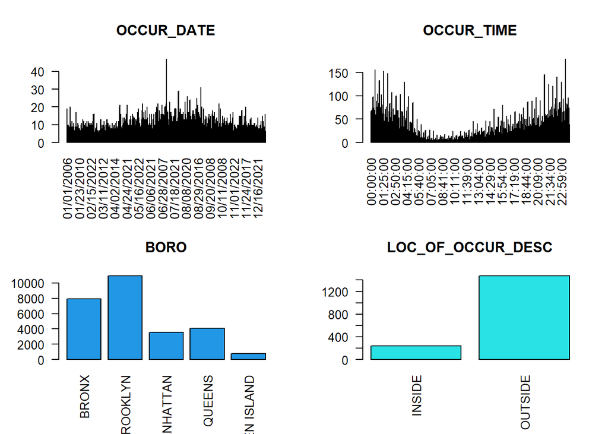

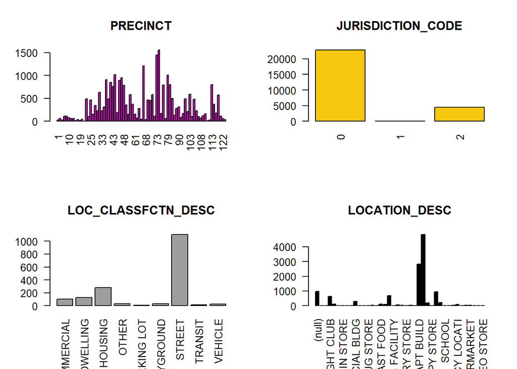

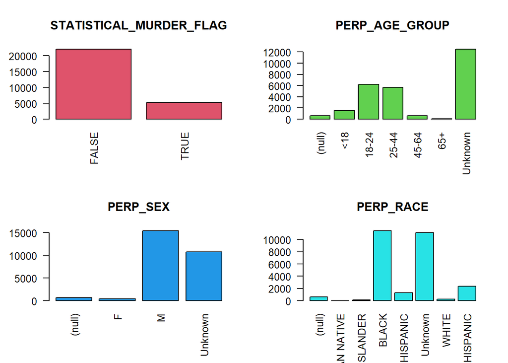

```r
par(mfrow = c(2,2))
for (i in 2:16){
      barplot(table(nypd_shooting[i]), col = i, las = 2, main = colnames(nypd_shooting)[i])
}
```

[figure not shown]

```r
par(mfrow = c(1,1))
```

*Observations*

Looking at the above graphs, we can see different patterns.

I am more interested diving deep into perpetrator and victims age group,Sex and Race and see if are any particular group are most impacted.

**Relation of Gender & shooting incidents**

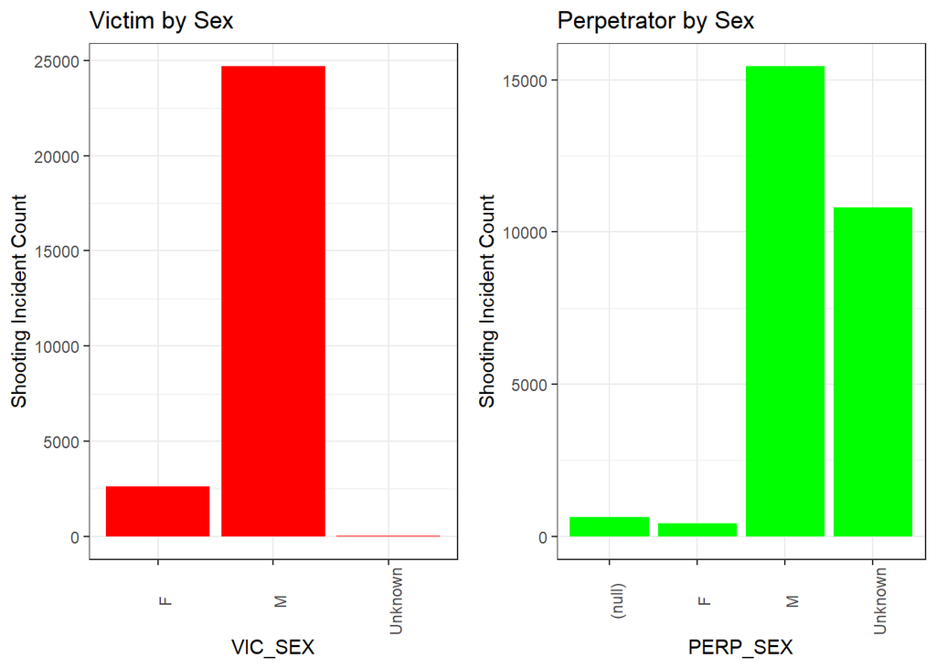

```r
Vic_race =nypd_shooting %>%
  ggplot(aes(VIC_SEX)) +
  geom_bar(fill = "Red")+
  theme_bw()+
  ggtitle("Victim by Sex") +
  ylab("Shooting Incident Count")+
  theme(axis.text.x = element_text(angle = 90))
perp_race = nypd_shooting %>%
  ggplot(aes(PERP_SEX)) +
  geom_bar(fill = "Green")+
  theme_bw()+
  ggtitle("Perpetrator by Sex") +
  ylab("Shooting Incident Count")+
  theme(axis.text.x = element_text(angle = 90))
grid.arrange(Vic_race, perp_race, newpage = TRUE,
             layout_matrix = matrix(1:2, byrow = TRUE, 2, 2))
```

**Observation & Discussion**

We can see that me are much more likely to be involved in shooting incidents than women.

**Victim Age Group & shooting incidents**

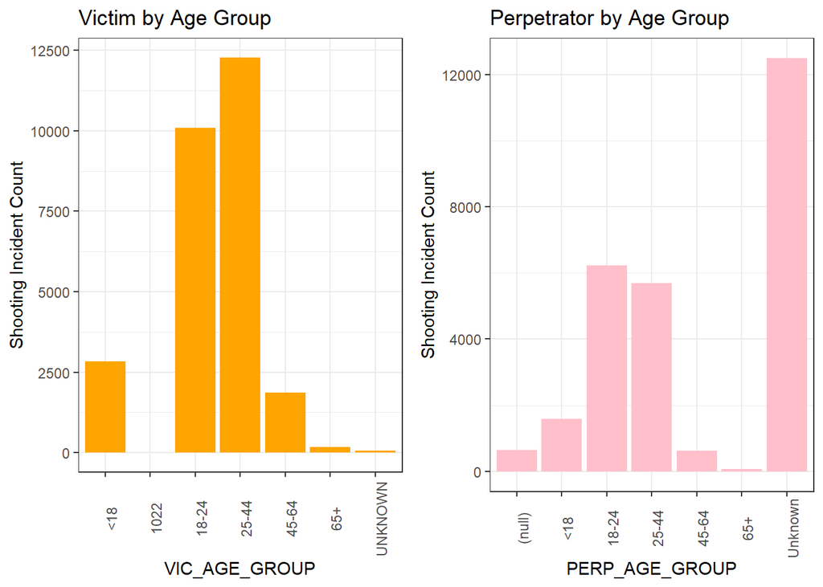

```r
Vic_race =nypd_shooting %>%
  ggplot(aes(VIC_AGE_GROUP)) +
  geom_bar(fill = "Orange")+
  theme_bw()+
  ggtitle("Victim by Age Group") +
  ylab("Shooting Incident Count")+
  theme(axis.text.x = element_text(angle = 90))

perp_race = nypd_shooting %>%
  ggplot(aes(PERP_AGE_GROUP)) +
  geom_bar(fill = "Pink")+
  theme_bw()+
  ggtitle("Perpetrator by Age Group") +
  ylab("Shooting Incident Count")+
  theme(axis.text.x = element_text(angle = 90))

grid.arrange(Vic_race, perp_race, newpage = TRUE,
             layout_matrix = matrix(1:2, byrow = TRUE, 2, 2))
```

**Observation & Discussion**

We can see for the above graph the Age Group 18-24 and 25-44 accounts for the victim and similar age group are contribute for the perpetrator, which aligns with my intuition that younger individuals tend to engage in more risky behavior

One caveat on the perpetrator observation is there are significant of perpetrator whose Age Group is unknown. Hence further data collection will be needed in order make any conclusion

**Victim races relation to shooting incidents**

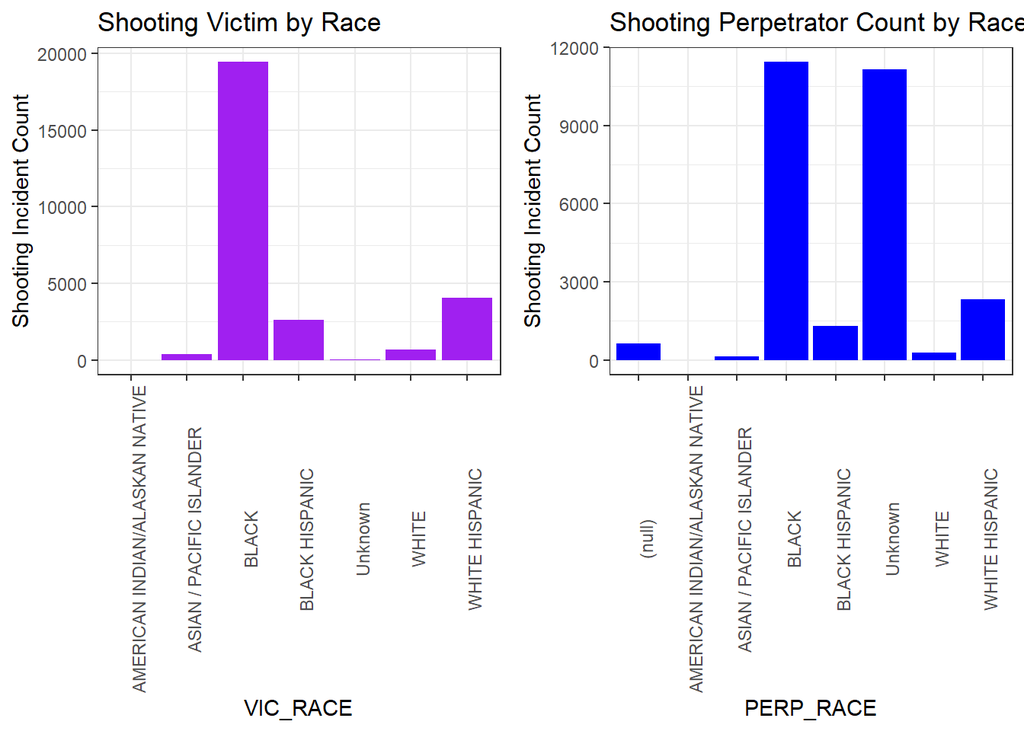

```r
Vic_race =nypd_shooting %>%
  ggplot(aes(VIC_RACE)) +
  geom_bar(fill = "Purple")+
  theme_bw()+
  ggtitle("Shooting Victim by Race") +
  ylab("Shooting Incident Count")+
  theme(axis.text.x = element_text(angle = 90))

perp_race = nypd_shooting %>%
  ggplot(aes(PERP_RACE)) +
  geom_bar(fill = "Blue")+
  theme_bw()+
  ggtitle("Shooting Perpetrator Count by Race") +
  ylab("Shooting Incident Count")+
  theme(axis.text.x = element_text(angle = 90))


grid.arrange(Vic_race, perp_race, newpage = TRUE,
             layout_matrix = matrix(1:2, byrow = TRUE, 2, 2))
```

**Observation & Discussion**

We can observe that a disproportionately large count of shooting incident victims as well perpetrators are **Black**, followed by **White Hispanic and Black Hispanic**.

I will go further on this observation and build a model to check if there is any correlation between Perpetrator and Victim Race especially black on black crime.

### Fatal Shootings

I now want to check if the above (generic) trend follows for the fatal shooting

**Victim age group & shooting incidents**

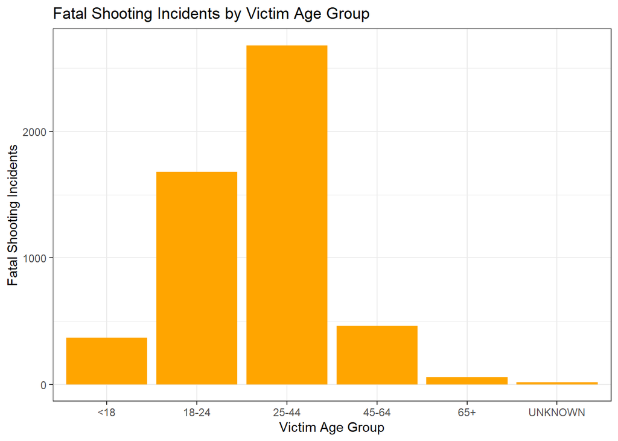

```r
nypd_shooting %>%
  filter(STATISTICAL_MURDER_FLAG == TRUE) %>%
  ggplot(aes(x = VIC_AGE_GROUP)) +
  geom_bar(fill = "Orange")+
  theme_bw()+
  labs(x = "Victim Age Group",
       y = "Fatal Shooting Incidents",
       title = "Fatal Shooting Incidents by Victim Age Group")
```

**Observation & Discussion** We can see quite clearly from the bar graph above, 18-24, 25-44 dominate the proportion of fatal victims as we have seen on overall victims above

**Fatal Victim sex & shooting incidents**

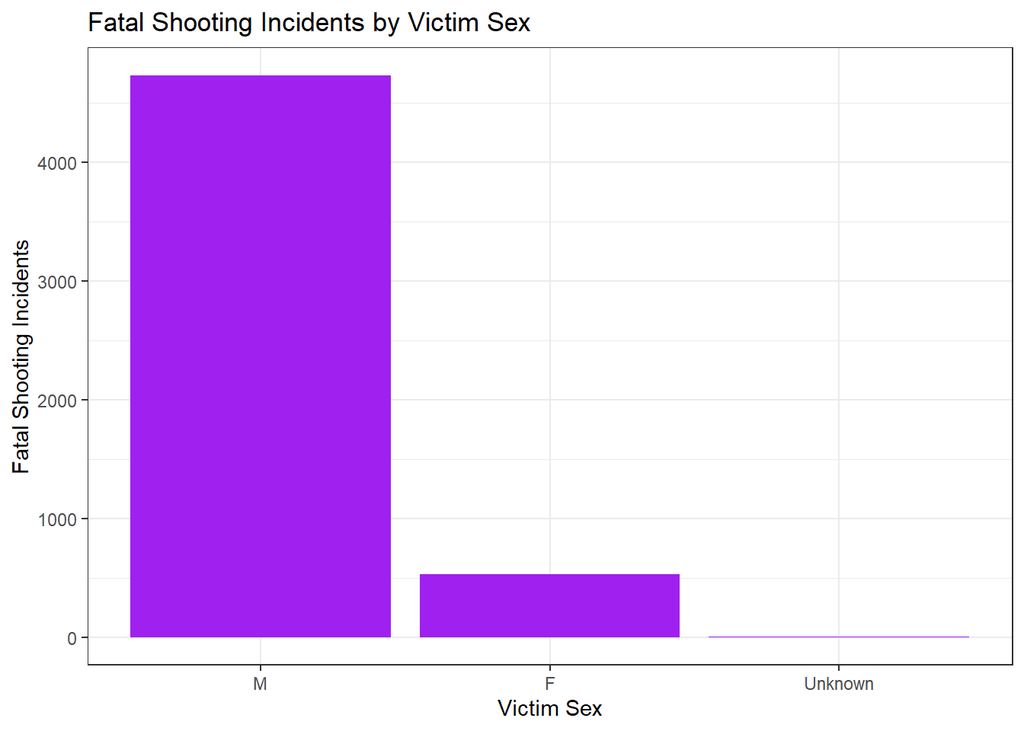

```r
nypd_shooting %>%
  filter(STATISTICAL_MURDER_FLAG == TRUE) %>%
  ggplot(aes(x = fct_infreq(VIC_SEX))) + # Display by frequency.
  geom_bar(stat = 'count')+
  geom_bar(fill = "Purple")+
  theme_bw()+
  labs(x = "Victim Sex",
       y = "Fatal Shooting Incidents",
       title = "Fatal Shooting Incidents by Victim Sex")
```

**Observation & Discussion**

Again majority of fatal victims are male as expected

**Fatal Victim race & shooting incidents**

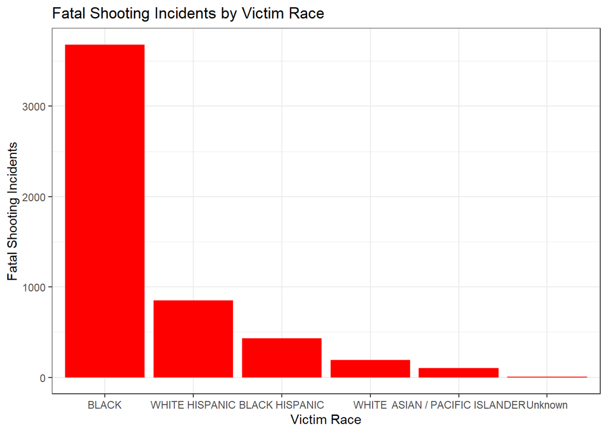

```r
nypd_shooting %>%
  filter(STATISTICAL_MURDER_FLAG == TRUE) %>%
  ggplot(aes(x = fct_infreq(VIC_RACE))) + # Display by frequency.
  geom_bar(stat = 'count')+
  geom_bar(fill = "Red")+
  theme_bw()+
  labs(x = "Victim Race",
       y = "Fatal Shooting Incidents",
       title = "Fatal Shooting Incidents by Victim Race")
```

**Observation & Discussion**

We again see the similar tred as highest number of fatal victims are black and white Hispanic